# NumPy and matplotlib

- https://numpy.org/
- https://matplotlib.org/

# 3a

- Generate a sine function in a range y_sin = np.sin(x).
  - Please use numpy.arange to generate the x-axis from 0 to 3 pi with a step size 0.1. https://numpy.org/doc/stable/reference/generated/numpy.arange.html

```python
import math

# Print the value of pi
print (math.pi)
```

```
3.141592653589793
```

```python
import numpy as np

# Compute the x and y coordinates for points on sine and cosine curves
x = np.arange( 0 , 9.5 , 0.1)
y_sin = np.sin(x)
print(x)
print(y_sin)
```

```
[0.  0.1 0.2 0.3 0.4 0.5 0.6 0.7 0.8 0.9 1.  1.1 1.2 1.3 1.4 1.5 1.6 1.7
 1.8 1.9 2.  2.1 2.2 2.3 2.4 2.5 2.6 2.7 2.8 2.9 3.  3.1 3.2 3.3 3.4 3.5
 3.6 3.7 3.8 3.9 4.  4.1 4.2 4.3 4.4 4.5 4.6 4.7 4.8 4.9 5.  5.1 5.2 5.3
 5.4 5.5 5.6 5.7 5.8 5.9 6.  6.1 6.2 6.3 6.4 6.5 6.6 6.7 6.8 6.9 7.  7.1
 7.2 7.3 7.4 7.5 7.6 7.7 7.8 7.9 8.  8.1 8.2 8.3 8.4 8.5 8.6 8.7 8.8 8.9
 9.  9.1 9.2 9.3 9.4]
[ 0.          0.09983342  0.19866933  0.29552021  0.38941834  0.47942554
  0.56464247  0.64421769  0.71735609  0.78332691  0.84147098  0.89120736
  0.93203909  0.96355819  0.98544973  0.99749499  0.9995736   0.99166481
  0.97384763  0.94630009  0.90929743  0.86320937  0.8084964   0.74570521
  0.67546318  0.59847214  0.51550137  0.42737988  0.33498815  0.23924933
  0.14112001  0.04158066 -0.05837414 -0.15774569 -0.2555411  -0.35078323
 -0.44252044 -0.52983614 -0.61185789 -0.68776616 -0.7568025  -0.81827711
 -0.87157577 -0.91616594 -0.95160207 -0.97753012 -0.993691   -0.99992326
 -0.99616461 -0.98245261 -0.95892427 -0.92581468 -0.88345466 -0.83226744
 -0.77276449 -0.70554033 -0.63126664 -0.55068554 -0.46460218 -0.37387666
 -0.2794155  -0.1821625  -0.0830894   0.0168139   0.1165492   0.21511999
  0.31154136  0.40484992  0.49411335  0.57843976  0.6569866   0.72896904
  0.79366786  0.85043662  0.8987081   0.93799998  0.96791967  0.98816823
  0.99854335  0.99894134  0.98935825  0.96988981  0.94073056  0.90217183
  0.85459891  0.79848711  0.7343971   0.66296923  0.58491719  0.50102086
  0.41211849  0.31909836  0.22288991  0.12445442  0.02477543]
```

# 3b

- Please search matplotlib in my file lec02 Introduction to python.ipynb and use the commands there to plot (x, y_sin).

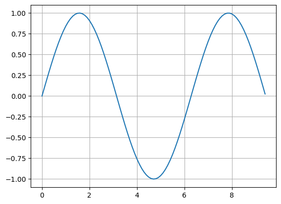

```python
import matplotlib.pyplot as plt
plt.plot( x , y_sin )
plt.grid()
```

# 3c

- What happen to the picture if the step size of x is changed from 0.1 to 1.
  - This exercise illustates the tradeoff between storage space and the output quality.

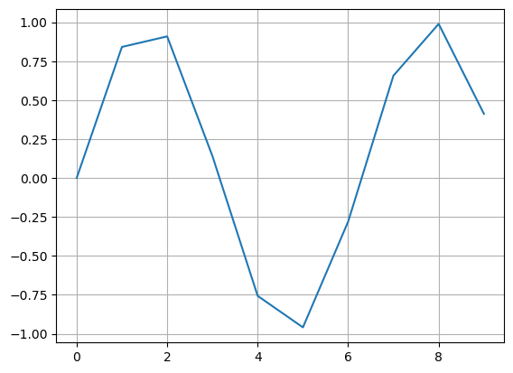

```python
x = np.arange(0, 9.5, 1)
y_sin = np.sin(x)
plt.plot(  x , y_sin )
plt.grid()
```

# 3d

- Please imitate the command plt.subplot in the file "lec02 Introduction to python.ipynb" to plot 4 pictures of np.sin(x), np.cos(x), np.power(x, 3), np.power(x, 0.5), respectively, where x = np.arange(0, 3 * np.pi, 0.1) with correct title.
- For the first upper-left-corner picture, it is plt.subplot(2, 2, 1).
- Please google plt.subplot and use the official webpage https://matplotlib.org/stable/api/_as_gen/matplotlib.pyplot.subplot.html to understand the meaning the arguments and the corresponding example.

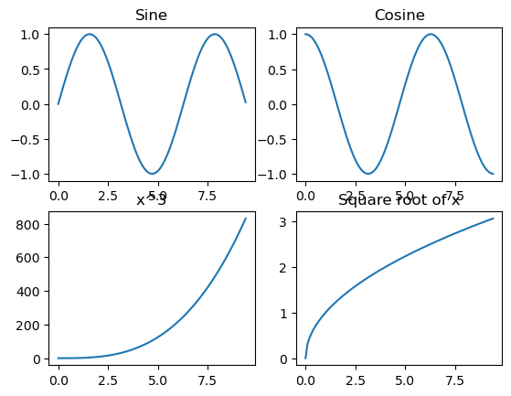

```python
import numpy as np
import matplotlib.pyplot as plt

# Compute the x and y coordinates for points on sine and cosine curves
x = np.arange( 0, 3 * np.pi , 0.1 )
y_sin = np.sin( x )
y_cos = np.cos( x )

# Set up a subplot grid that has height 2 and width 1,
# and set the first such subplot as active.
plt.subplot( 2 , 2 , 1 )
# Make the first plot
plt.plot( x , y_sin )
plt.title('Sine')

# Set the second subplot as active, and make the second plot.
plt.subplot( 2 , 2 , 2 )
plt.plot(x, y_cos)
plt.title('Cosine')

plt.subplot( 2 , 2 , 3 )
plt.plot(x, np.power(x, 3))
plt.title('x^3')

plt.subplot( 2 , 2 , 4 )
plt.plot(x, np.power(x, .5))
plt.title('Square root of x')

# Show the figure.
plt.show()
```

# 3e

- What is the total number of plots for plt.subplot(3, 2, *)?

Answer: 3 * 2 = 6

# 3f

- The words in the default setting will collapse together which is not beautiful. Please search “layout matplotlib” to find out the commands to fix this problem.
  - tight_layout()

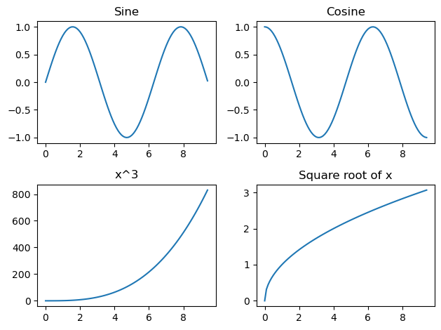

```python
#Number 3c - Optional

# Set up a subplot grid that has height 2 and width 1,
# and set the first such subplot as active.
plt.subplot( 2 , 2 , 1 )

# Make the first plot
plt.plot(x, y_sin)
plt.title('Sine')

# Set the second subplot as active, and make the second plot.
plt.subplot( 2 , 2 , 2 )
plt.plot(x, y_cos)
plt.title('Cosine')

plt.subplot( 2 , 2 , 3 )
plt.plot(x, np.power(x, 3))
plt.title('x^3')

plt.subplot( 2 , 2 , 4 )
plt.plot(x, np.power(x, .5))
plt.title('Square root of x')

# Show the figure.
plt.tight_layout()  #add this command to fix the spacing between words
plt.show()
```